# In-Class_Ex06 - Local & Global Measures of Spatial Autocorrelation

Author

Han Ming Yan

Published

September 23, 2024

Modified

October 8, 2024

# 1 Installing and Loading the R Packages

```r
pacman::p_load(sf, tidyverse, tmap, sfdep)
```

### 1.0.1 **The Study Area and Data**

Two data sets will be used in this hands-on exercise, they are:

- Hunan province administrative boundary layer at county level. This is a geospatial data set in ESRI shapefile format.
- Hunan_2012.csv: This csv file contains selected Hunan’s local development indicators in 2012.

## 1.1 **Getting the Data Into R Environment**

### 1.1.1 **Import shapefile into r environment**

The code chunk below uses [`st_read()`](https://r-spatial.github.io/sf/reference/st_read.html) of **sf** package to import Hunan shapefile into R. The imported shapefile will be **simple features** Object of **sf**.

```r
hunan <- st_read(dsn = "data/geospatial",
                 layer = "Hunan")
```

### 1.1.2 **Import csv file into r environment**

Next, we will import *Hunan_2012.csv* into R by using [`read_csv()`](https://readr.tidyverse.org/reference/read_delim.html) of **readr** package. The output is R data frame class.

```r
hunan2012 <- read_csv("data/aspatial/Hunan_2012.csv")
```

### 1.1.3 **Performing relational join**

The code chunk below will be used to update the attribute table of *hunan*’s SpatialPolygonsDataFrame with the attribute fields of *hunan2012* dataframe. This is performed by using [`left_join()`](https://dplyr.tidyverse.org/reference/mutate-joins.html) of **dplyr** package.

```r
hunan_GDPPC <- left_join(hunan,hunan2012) %>%
  dplyr::select(1:4, 7, 15)
```

## 1.2 **Visualising Regional Development Indicator**

Now, we are going to prepare a basemap and a choropleth map showing the distribution of GDPPC 2012 by using *qtm()* of **tmap** package.

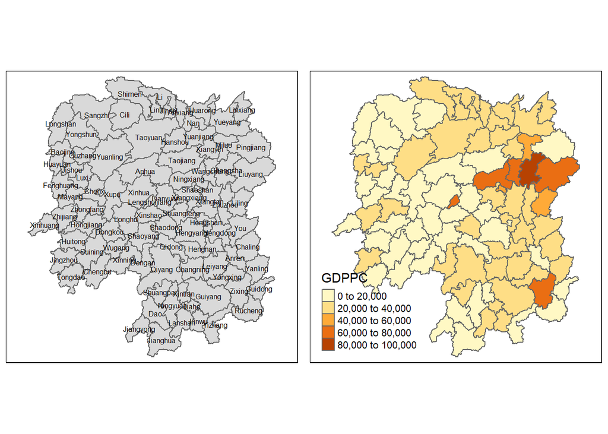

```r
basemap <- tm_shape(hunan) +
  tm_polygons() +
  tm_text("NAME_3", size=0.5)

gdppc <- qtm(hunan_GDPPC, "GDPPC")
tmap_arrange(basemap, gdppc, asp=1, ncol=2)
```

```r
wm_q <- hunan_GDPPC %>%
  dplyr::mutate(nb = st_contiguity(geometry),
         wt = st_weights(nb,
                         style = "W"),
         .before = 1)
```

# 2 Computing Global Moran’ I

```r
moranI <- global_moran(wm_q$GDPPC,
                       wm_q$nb,
                       wm_q$wt)
glimpse(moranI)
```

```
List of 2
 $ I: num 0.301
 $ K: num 7.64
```

## 2.1 Performing Global Moran’s I test

In general, Moran’s I test will be performed instead of just computing the Moran’s I statistics. With sfdep package, Moran’s I test can be performed using global_moran_test() as shown in the code chunk below.

```r
global_moran_test(wm_q$GDPPC,
                  wm_q$nb,
                  wm_q$wt)
```

```
    Moran I test under randomisation

data:  x
weights: listw

Moran I statistic standard deviate = 4.7351, p-value = 1.095e-06
alternative hypothesis: greater
sample estimates:
Moran I statistic       Expectation          Variance
      0.300749970      -0.011494253       0.004348351
```

## 2.2 Performing Global Moran’s I permutation test

In practice, Monte Carlo simulation should be used to perform the statistical test. For sfdep, it is supported by global_moran_perm()

```r
set.seed(1234)
```

```r
global_moran_perm(wm_q$GDPPC,
                  wm_q$nb,
                  wm_q$wt,
                  nsim = 99)
```

```
    Monte-Carlo simulation of Moran I

data:  x
weights: listw
number of simulations + 1: 100

statistic = 0.30075, observed rank = 100, p-value < 2.2e-16
alternative hypothesis: two.sided
```

## 2.3 Computing local Moran’s I

Compute Local Moran’s I of GDPPC at county level by using local_moran() of the sfdep package.

```r
lisa <- wm_q %>%
  dplyr::mutate(local_moran = local_moran(
    GDPPC, nb, wt, nsim = 99),
    .before = 1) %>%
  unnest(local_moran)
```

p_ii is base method, p_ii_sim is using the simulation method, p_folded_sim is using the k-fold method, p_ii_sim has no replacement, p_folded numbers are lower but roughly the method is still the same.

To ensure consistency, stay with 1 type of p-value (either p_ii_sim or p_folded_sim)

key thing is the mean and median, skewness can be both positive and negative numbers, i can sort it to make it easier to read

```r
# to measure skewness
median(lisa$skewness) # -0.6968806
```

```
[1] -0.6968806
```

```r
# to see the mean skewness across the whole data
mean(lisa$skewness) # -0.2233379
```

```
[1] -0.2233379
```

```r
# can also plot it out into a histogram to visualise better to see the skewness
```

- excessive skewness -> use median columns
- if close to 0 skewness -> use mean columns

## 2.4 Visualising local Moran’s I and p-value

the next map is prepared using this chunk of code

```r
tmap_mode("plot")
```

```
tmap mode set to plotting
```

```
Variable(s) "ii" contains positive and negative values, so midpoint is set to 0. Set midpoint = NA to show the full spectrum of the color palette.
```

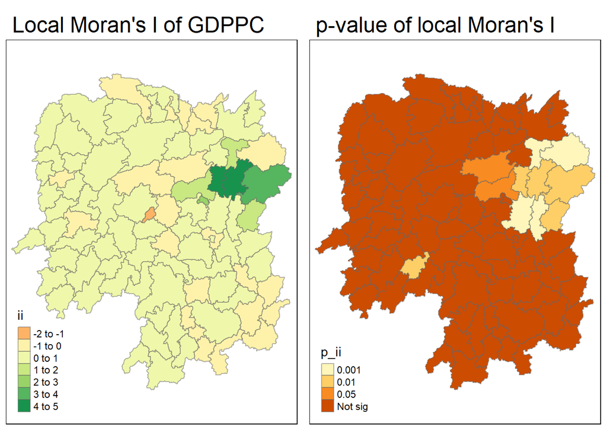

```r
map1 <- tm_shape(lisa) +
  tm_fill("ii") +
  tm_borders(alpha = 0.5) +
  tm_view(set.zoom.limits = c(6,8)) +
  tm_layout(
    main.title = "Local Moran's I of GDPPC",
    main.title.size = 1.5)

map2 <- tm_shape(lisa) +
  tm_fill("p_ii",
          breaks = c(0, 0.001, 0.01, 0.05, 1),
          labels = c("0.001", "0.01", "0.05", "Not sig")) +
  tm_borders(alpha = 0.5) +
  tm_layout(
    main.title = "p-value of local Moran's I",
    main.title.size = 1.5
  )

tmap_arrange(map1, map2, ncol = 2)
```

# 3 Visualising LISA map

LISA map is a categorical map showing outliers and clusters. There are two types of outliers namely: High-Low and Low-High outliers. Likewise there are two types of clusters namely: High-High and Low-Low clusters. In fact, LISA map is an interpreted map by combining local Moran’s I of geographical areas and their respective p-values.

In this case the LISA categories are the mean, median and pysal. In general, classification in mean will be used as shown in the code chunk below.

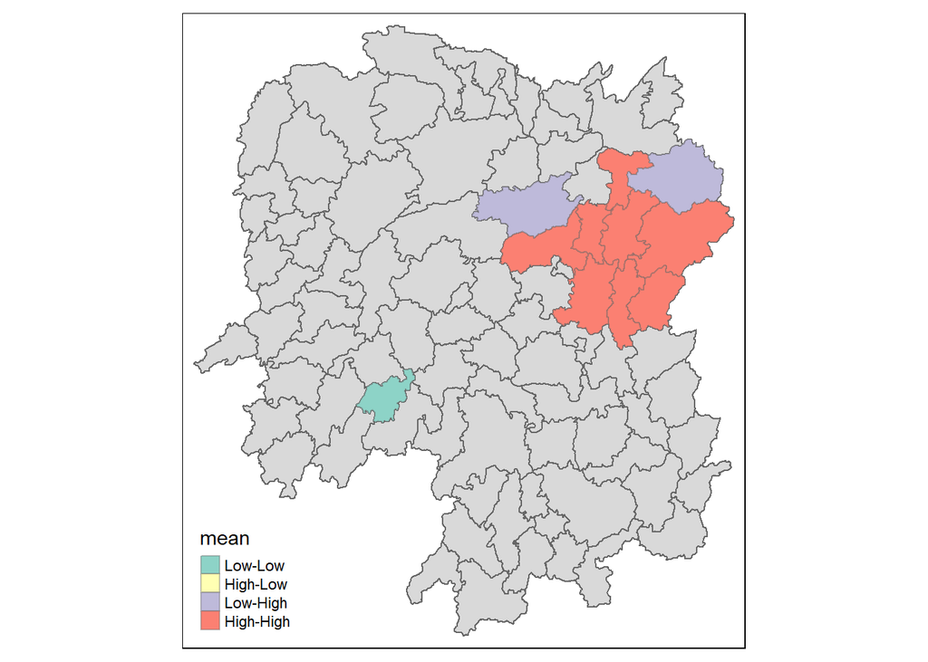

```r
lisa_sig <- lisa %>%
  filter(p_ii < 0.05)
tm_shape(lisa) +
  tm_polygons() +
  tm_borders(alpha = 0.5) +
tm_shape(lisa_sig) +
  tm_fill("mean") +
  tm_borders(alpha = 0.4)
```

## 3.1 Computing local Gi* statistics

```r
wm_idw <- hunan_GDPPC %>%
  mutate(
    nb = st_contiguity(geometry),
    wts = st_inverse_distance(
      nb, geometry,
      scale = 1, alpha = 1
    ),
    .before = 1
  )
```

```
! Polygon provided. Using point on surface.
```

we will now compute the local Gi* by using the code chunk below

```r
HCSA <- wm_idw %>%
  mutate(local_Gi = local_gstar_perm(
    GDPPC, nb, wt, nsim = 99
  ), .before = 1) %>%
  unnest(local_Gi)

HCSA
```

```
Simple feature collection with 88 features and 18 fields
Geometry type: POLYGON
Dimension:     XY
Bounding box:  xmin: 108.7831 ymin: 24.6342 xmax: 114.2544 ymax: 30.12812
Geodetic CRS:  WGS 84
# A tibble: 88 × 19
   gi_star cluster   e_gi     var_gi std_dev p_value p_sim p_folded_sim skewness
     <dbl> <fct>    <dbl>      <dbl>   <dbl>   <dbl> <dbl>        <dbl>    <dbl>
 1  0.0416 Low     0.0114 0.00000641  0.0493 9.61e-1  0.7          0.35    0.875
 2 -0.333  Low     0.0106 0.00000384 -0.0941 9.25e-1  1            0.5     0.661
 3  0.281  High    0.0126 0.00000751 -0.151  8.80e-1  0.9          0.45    0.640
 4  0.411  High    0.0118 0.00000922  0.264  7.92e-1  0.6          0.3     0.853
 5  0.387  High    0.0115 0.00000956  0.339  7.34e-1  0.62         0.31    1.07
 6 -0.368  High    0.0118 0.00000591 -0.583  5.60e-1  0.72         0.36    0.594
 7  3.56   High    0.0151 0.00000731  2.61   9.01e-3  0.06         0.03    1.09
 8  2.52   High    0.0136 0.00000614  1.49   1.35e-1  0.2          0.1     1.12
 9  4.56   High    0.0144 0.00000584  3.53   4.17e-4  0.04         0.02    1.23
10  1.16   Low     0.0104 0.00000370  1.82   6.86e-2  0.12         0.06    0.416
# ℹ 78 more rows
# ℹ 10 more variables: kurtosis <dbl>, nb <nb>, wts <list>, NAME_2 <chr>,
#   ID_3 <int>, NAME_3 <chr>, ENGTYPE_3 <chr>, County <chr>, GDPPC <dbl>,
#   geometry <POLYGON [°]>
```

```
Variable(s) "gi_star" contains positive and negative values, so midpoint is set to 0. Set midpoint = NA to show the full spectrum of the color palette.
```

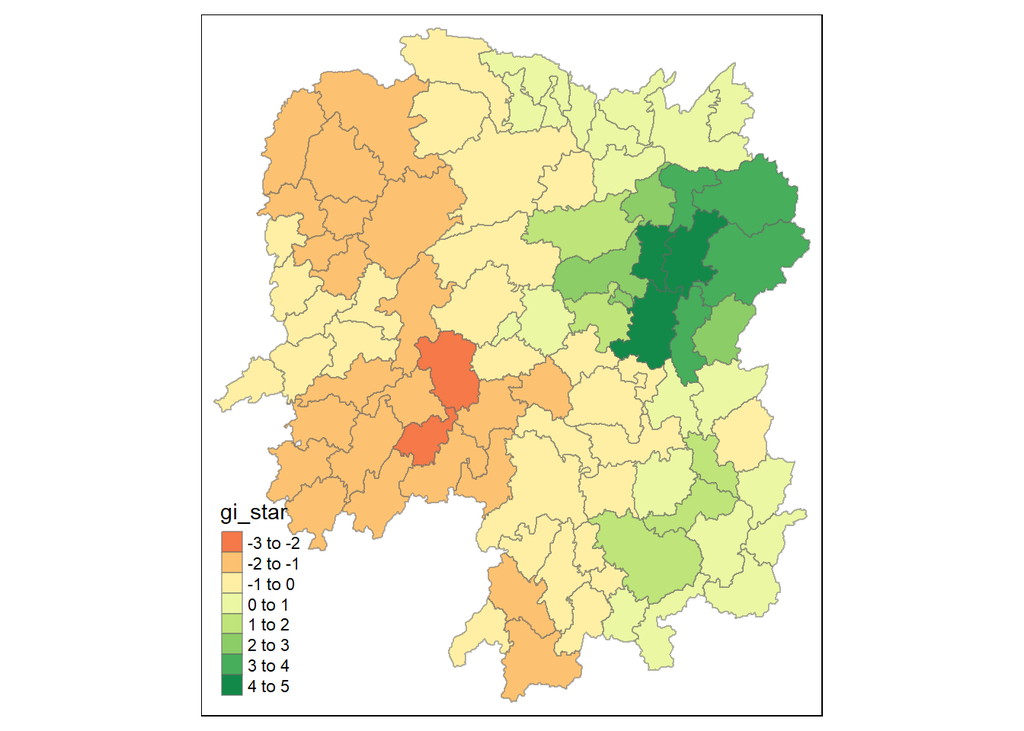

```r
tm_shape(HCSA) +
  tm_fill("gi_star") +
  tm_borders(alpha = 0.5)
```

# 4 Visualising hot spot and cold spot areas

```
Variable(s) "gi_star" contains positive and negative values, so midpoint is set to 0. Set midpoint = NA to show the full spectrum of the color palette.
```

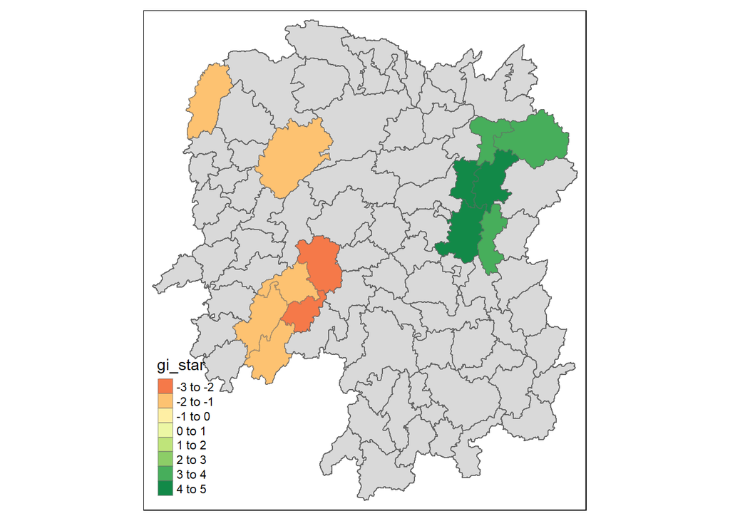

```r
HCSA_sig <- HCSA %>%
  filter(p_sim < 0.05)
tm_shape(HCSA) +
  tm_polygons()+
  tm_borders(alpha = 0.5) +
tm_shape(HCSA_sig) +
  tm_fill("gi_star") +
  tm_borders(alpha = 0.4)
```